# Preprocessing

Emily Wahlenmayer

April 23, 2026

```r
knitr::opts_chunk$set(echo = TRUE,
                      fig.align = "center",
                      # send any figure output to this folder
                      fig.path = "/local/workdir/erw98/Brassica_Growth_2026/figures/03_Preprocessing")
```

# Goals

The goal with this file is to pre-process any other contaminants and unexpected ASVs from our sample. We will need to:

1. Remove any contaminating ASVs that are **chloroplasts**.
2. Remove ASVs that are **mitochondria**.
3. Evaluate any ASVs from the **negative controls**. Then, remove negative controls.
4. Evaluate the mock community or **positive control** to learn the accuracy of sequencing.
5. Check for **reverse complements**.
6. Check the **sequencing depth** of samples. Remove samples that obviously have too few reads.
7. Add the metadata for class dataset (Note: Your data may already be in your `sample_data()`).
8. Write a `preprocessed_physeq` to be used in the next step of our workflow.

## Input

Here, we will start with the phyloseq object that we created in 02_AssignASVs.Rmd

1. **Raw phyloseq object**: We will need `data/02_AssignASVs/raw_phyloseq.RData`.
2. **Mock Amplicon Fasta**: Please copy over the `mock_amplicons.fasta` from `/workdir/in_class_data/` to your `data/03_PreProcessing` folder.

## Output

1. We will write out a complex R data object known as an **S4** object, which in this case is known as a phyloseq output. We will store this in `data/03_PreProcessing/preprocessed_phyloseq.RData`.

# Set up the Environment

## Set the seeds and threads

```r
# Set the seed for reproducibility
set.seed(238428)
```

## Timing of this script

Let’s record how long this file took to run on the class server, which we will record at the end of the script.

```r
# What time did we start running this script?
start_time <- Sys.time()
```

## Load packages

```r
# Load packages
pacman::p_load(devtools, phyloseq, Biostrings, tidyverse, dada2, patchwork,
               # Note to add ggpubr & rstatix!!
               ggpubr, rstatix, install = FALSE)
```

# Load Phyloseq Data

```r
# Load the data
load("/local/workdir/erw98/Brassica_Growth_2026/data/raw_physeq.RData")

# Look at the data
raw_physeq
```

```
## phyloseq-class experiment-level object
## otu_table()   OTU Table:         [ 4664 taxa and 252 samples ]
## sample_data() Sample Data:       [ 252 samples by 34 sample variables ]
## tax_table()   Taxonomy Table:    [ 4664 taxa by 9 taxonomic ranks ]
```

```r
#load("/local/workdir/erw98/Brassica_Growth_2026/data/02_AssigningASVs/ASV_taxonomy.tsv")
```

# Clean up the data

**Chloroplasts** and **mitochondria** need to be removed from 16S datasets because they contain their own 16S rRNA genes, which are evolutionarily derived from bacteria. These organelles can be unintentionally amplified during PCR, especially in samples from plants (chloroplasts) or animals (mitochondria), leading to misleading results by inflating microbial diversity.

This is explained by the endosymbiotic theory, which proposes that mitochondria and chloroplasts originated from free-living bacteria that were engulfed by ancestral eukaryotic cells. Over time, they became permanent, symbiotic organelles with their own genomes. Because of this bacterial ancestry, their 16S rRNA genes are similar to those targeted in bacterial 16S profiling, even though they are part of the host organism and not part of the microbial community being studied.

Removing these sequences ensures the analysis reflects true bacterial and archaeal diversity in the environment or host.

## 1. Remove Chloroplasts

```r
# Let's take a quick look at the taxa table
# View(tax_df) # Let's see where chloroplasts are and also mitochondria

# Make new physeq without chloroplasts
noChloros_physeq <-
  raw_physeq %>%
  # rm chloroplasts, which are Order
  subset_taxa(Order != "Chloroplast" | is.na(Order))

# How many taxa were chloroplasts?
num_chloro_ASVs <- ntaxa(raw_physeq) - ntaxa(noChloros_physeq)
num_chloro_ASVs #694
```

```
## [1] 694
```

```r
# Intuition check
#noChloros_physeq %>%
#  tax_table() %>%
#  data.frame() %>%
#  View()
```

There were 694 ASVs that were chloroplasts.

## 2. Remove Mitochondria

```r
# remove mitochondria
noChlorosMitos_physeq <-
  noChloros_physeq %>%
  subset_taxa(Family != "Mitochondria" | is.na(Family)) %>%
  prune_samples(!grepl("Dup", sample_names(.)), .)


# How many mitochondrial ASVs?
num_mito_ASVs <- ntaxa(noChloros_physeq) - ntaxa(noChlorosMitos_physeq)
num_mito_ASVs #27
```

```
## [1] 27
```

```r
# Let's take a quick look
noChlorosMitos_physeq
```

```
## phyloseq-class experiment-level object
## otu_table()   OTU Table:         [ 3943 taxa and 252 samples ]
## sample_data() Sample Data:       [ 252 samples by 34 sample variables ]
## tax_table()   Taxonomy Table:    [ 3943 taxa by 9 taxonomic ranks ]
```

There were 27 ASVs that were mitochondria in the data set.

INTERPRETATION #1: How many chloroplast and/or mitochondrial ASVs in your dataset? Does this seem reasonable?

```r
# How many total asvs were removed from chloros and mitos?
ntaxa(raw_physeq) - ntaxa(noChlorosMitos_physeq) #721
```

```
## [1] 721
```

```r
# proportion of asvs kept?
ntaxa(noChlorosMitos_physeq)/ntaxa(raw_physeq) #84.54%
```

```
## [1] 0.8454117
```

It seems I have no controls.

### 3a. Evaluate Negative Control ASVs in Samples vs Controls

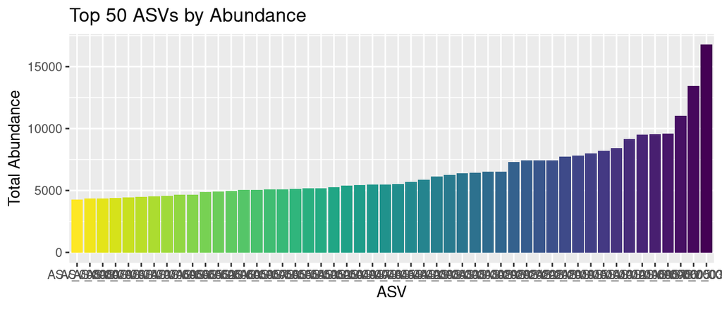

```r
asv_abundance_df <-
  noChlorosMitos_physeq %>%
  otu_table() %>%
  as("matrix") %>%
  rowSums() %>%
  data.frame(Abundance = .) %>%
  tibble::rownames_to_column("ASV") %>%
  arrange(desc(Abundance))

asv_abundance_df <- asv_abundance_df %>%
  dplyr::filter(Abundance > 0)

top_n <- 50

#Plot ASV Abundance (top_n)
asv_abundance_df %>%
  dplyr::slice_head(n = top_n) %>%
  ggplot(aes(x = reorder(ASV, Abundance),
             y = Abundance,
             fill = ASV)) +
  geom_col() +
   scale_fill_viridis_d() +   # discrete colors (not gradient)
  #not exactly what I wanted but ok
  #coord_flip() + #make into horizontal bars instead
  labs(x = "ASV",
       y = "Total Abundance",
       title = paste("Top", top_n, "ASVs by Abundance")) +
  theme(
    legend.position = "none"
  )
```

```r
#
# as.data.frame(tax_table(noChlorosMitos_physeq)) %>%
#   dplyr::filter(ASV == "ASV_0001")
sum(taxa_sums(noChlorosMitos_physeq) > 0) #3943
```

```
## [1] 3943
```

```r
#Removing any ASVs <10
physeq_filtered <- prune_taxa(taxa_sums(noChlorosMitos_physeq) > 10, noChlorosMitos_physeq)
sum(taxa_sums(physeq_filtered) > 0) #3299
```

```
## [1] 3299
```

```r
# #Boiling down to Genus level
# physeq_genus <- tax_glom(physeq_filtered, taxrank = "Genus")
# ntaxa(physeq_genus) #291
# #This is closer to the number of ASVs in the paper

#Make a real df from this and plot it again now that I've narrowed it down:

# genus_abundance_df <-
#   physeq_genus %>%
#   otu_table() %>%
#   as("matrix") %>%
#   rowSums() %>%
#   data.frame(Abundance = .) %>%
#   tibble::rownames_to_column("Genus")
# genus_abundance_df$Genus[is.na(genus_abundance_df$Genus)] <- "Unassigned"
#
#
# genus_abundance_df %>%
#   dplyr::arrange(desc(Abundance)) %>%
#   dplyr::slice_head(n = top_n) %>%
#   ggplot(aes(x = reorder(Genus, -Abundance),
#              y = Abundance,
#              fill = Genus)) +
#   geom_col() +
#   scale_fill_viridis_d() +
#   labs(x = "Genus",
#        y = "Total Abundance",
#        title = paste("Top", top_n, "Genera (Filtered ASVs ≥10 reads)")) +
#   theme_bw() +
#   theme(
#     axis.text.x = element_text(angle = 45, hjust = 1),
#     legend.position = "none"
#   )

ntaxa(noChlorosMitos_physeq)      # original ASVs
```

```
## [1] 3943
```

```r
ntaxa(physeq_filtered)            # after filtering
```

```
## [1] 3299
```

```r
# ntaxa(physeq_genus)               # after collapsing to Genus
# class(physeq_genus)
#3943, 3299, and 291
#don't know why the most abundant is on the left now




#####Residual from class (not running):######
# Make a phyloseq object with only the negative controls
#neg_control_samples <- c("Control")

# Create a phyloseq object with only negative controls
# neg_control_physeq <-
#   noChlorosMitos_physeq %>%
# subset_samples(., names %in% neg_control_samples) %>%
#   # force remove ASVs with 0 counts
#   prune_taxa(taxa_sums(.) > 0, .)
# noChlorosMitos_physeq <- noChlorosMitos_physeq %>%
#   { prune_taxa(taxa_sums(.) > 0, .) }
# # Let's take a look
# neg_control_physeq
# class(noChlorosMitos_physeq)
# taxa_sums(noChlorosMitos_physeq)
# # vector of negative control asvs
# neg_control_ASVs <-
#   neg_control_physeq %>%
#   tax_table() %>%
#   data.frame() %>%
#   dplyr::select(ASV) %>%
#   as.vector()
#
# # Visualize raw abundance values of control ASVs
# neg_control_physeq %>%
#   plot_bar(., "ASV", fill = "ASV")
#this plot doesn't work
```

#### Check Taxonomy

```r
# Let's zoom in only on these two that we care about!
# asv_negControls_df %>%
#   dplyr::filter(OTU %in% c("ASV_2399", "ASV_2424")) %>%
#   ggplot(aes(x = Sample_or_Control, y = Abundance,
#              color = Sample_or_Control, fill = Sample_or_Control)) +
#   geom_boxplot(alpha =0.3, outlier.shape = NA) +
#   geom_jitter() +
#   facet_wrap(.~ASV, scales = "free") +
#   scale_color_manual(values = c("firebrick3", "cornflowerblue")) +
#   scale_fill_manual(values = c("firebrick3", "cornflowerblue")) +
#   theme_bw() + theme(legend.position = "none")
```

INTERPRETATION #2: Did your dataset have any negative controls? If so, how many ASVs did you remove? Does that seem reasonable to you? No controls

# 4. Positive Controls

*What can we conclude about the mock community???*

INTERPRETATION #3: Did your dataset have a mock community? If so, what can you say about the accuracy of your sequencing run?

My dataset does not have a mock community.

## Remove the mock community and it’s ASVs

# 5. Reverse Complements

During PCR amplification, sequencing, or bioinformatics processing, it’s possible that some sequences get read in the reverse orientation, are assigned to the wrong strand, or are present as both the forward and reverse complement versions in your dataset. This is especially common when using non-strand-specific sequencing protocols, the pipeline doesn’t enforce consistent orientation, or working with merged paired-end reads and haven’t filtered by orientation yet.

## How to identify reverse complements?

- You can search your ASV or OTU table for reverse complement matches.
- If two sequences are reverse complements of each other, you can merge them and recalculate abundances.
- Tools like VSEARCH, USEARCH, or even custom scripts in R or Python can help identify reverse complements.
- Some pipelines (like DADA2) handle this automatically if you process all reads with the same orientation. This can be done in the `filterAndTrim()` step by using the `orient.fwd` parameter. But if you merge reads from multiple sources, it’s worth checking.

Reverse complements can show up in your dataset when identical sequences are read or processed in opposite orientations. If not accounted for, they can artificially inflate diversity and confuse your analyses. By searching for and collapsing reverse complements, you ensure that your 16S data is more accurate and biologically meaningful.

```r
# Pull out Taxa Table. Have to use noChlorosMitos because ASVs don't work on Genus
tax_table <-
  noChlorosMitos_physeq %>%
  tax_table() %>%
  data.frame()

#noChlorosMitos_physeq

#tax_table

# Grab ASV Sequences and Names
asv_names <- tax_table$ASV
asv_seqs <- tax_table$ASVseqs

# Create empty comparison matrix
asv_rev_comp <- matrix(nrow=length(asv_seqs), ncol = length(asv_seqs))

# Fix the names in the rows and columns
rownames(asv_rev_comp) <- asv_names
colnames(asv_rev_comp) <- asv_names

# Convert sequences to Biostrings
asv_dna <- DNAStringSet(asv_seqs)

# Inspect
head(asv_dna)
```

```
## DNAStringSet object of length 6:
##     width seq
## [1]   292 GTGTCAGCAGCCGCGGTAATACAGAGGGTGCAAG...GGGAGCAAACAGGATTAGATACCCCCGTAGTCC
## [2]   292 GTGCCAGCAGCCGCGGTAATACAGAGGGTGCAAG...GGGAGCAAACAGGATTAGATACCCCCGTAGTCC
## [3]   292 GTGTCAGCCGCCGCGGTAATACAGAGGGTGCAAG...GGGAGCAAACAGGATTAGATACCCCCGTAGTCC
## [4]   292 GTGTCAGCAGCCGCGGTAATACAGAGGGTGCAAG...GGGAGCAAACAGGATTAGATACCCGCGTAGTCC
## [5]   292 GTGTCAGCAGCCGCGGTAATACAGAGGGTGCAAG...GGGAGCAAACAGGATTAGAAACCCCCGTAGTCC
## [6]   292 GTGTCAGCAGCCGCGGTAATACGTAGGGTGCAAG...GGGAGCAAACAGGATTAGATACCCCCGTAGTCC
```

```r
# Construct reverse complement
asv_rev_dna <- reverseComplement(asv_dna)

# Now loop through every asv sequence to check
for(i in 1:length(asv_seqs)){ # For each asv sequence...
  match_vec <- asv_dna[i] == asv_rev_dna # Compare it to the reverse complement of every other sequence...
  asv_rev_comp[,i] <- match_vec # Write that logical vector as a new column
}

# Find how many TRUEs (matches) we have, divide by 2 because each pair occurs twice
cat("For", sum(asv_rev_comp) / 2,"ASVs, the reverse complement will need to be removed")
```

```
## For 5 ASVs, the reverse complement will need to be removed
```

# Interpretation 1

INTERPRETATION #4: Do you have any reverse complements in your dataset?

I have 5 reverse complements which is biologically insignificant. We do not merge them in this code.

# 6. Sequencing Depth

## How to deal with unequal sequencing depth?

We often normalize for sequencing depth before comparing samples using methods like:

- *Rarefaction*: Subsampling many times (typically 1,000 times) to an even depth.
- *Scaling*: Transform sample counts by multiplying by the ASV count by the minimum library size in the dataset.
- *Proportional normalization*: Converting to relative abundance (all ASV values within a sample add up to 1).
- *Statistical modeling*: DESeq2, which accounts for depth.

Let’s take a look!

```r
# The current data object
noChlorosMitos_physeq
```

```
## phyloseq-class experiment-level object
## otu_table()   OTU Table:         [ 3943 taxa and 252 samples ]
## sample_data() Sample Data:       [ 252 samples by 34 sample variables ]
## tax_table()   Taxonomy Table:    [ 3943 taxa by 9 taxonomic ranks ]
```

```r
summary(physeq_filtered)
```

```
##   Length    Class     Mode
##        1 phyloseq       S4
```

```r
# Make a metadata_df for joining
metadata_df <-
  physeq_filtered %>%
  sample_data() %>%
  data.frame()

# What is the library size/sequencing depth for each sample?
seqSums_df <-
  physeq_filtered %>%
  otu_table() %>%
  # Sum each sample column
  colSums() %>%
  data.frame() %>%
  rownames_to_column(var = "Run") %>%
  left_join(., metadata_df, by = "Run")

#Troubleshooting that
# otu_table(noChlorosMitos_physeq)
# taxa_are_rows(noChlorosMitos_physeq)
# rownames(noChlorosMitos_physeq)
# otu_mat <- as(otu_table(noChlorosMitos_physeq), "matrix")
# seqSums_df <- data.frame(
#   names = colSums(otu_mat)
# )
# seqSums_df <- data.frame(
#   names = names(colSums(otu_mat)),
#   seq_depth = colSums(otu_mat)
# )
# colnames(metadata_df)
# head(metadata_df)
# ###
# Rename second column
colnames(seqSums_df)[2] <- "TotalSeqs"

####
# check
dim(seqSums_df)
```

```
## [1] 252  35
```

```r
#View(seqSums_df)
#252 35

# Show the depth of samples
seqSums_df %>%
  dplyr::select(Run, TotalSeqs) %>%
  arrange(TotalSeqs) %>%
  head()
```

```
##           Run TotalSeqs
## 1 SRR11917052         0
## 2 SRR11917058         0
## 3 SRR11917074         0
## 4 SRR11917085         0
## 5 SRR11917092         0
## 6 SRR11917106         0
```

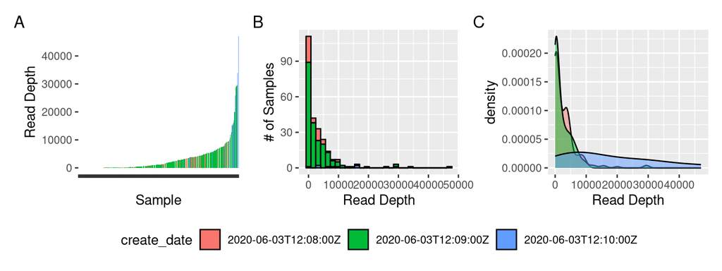

```r
# plot it as a bar plot
numSeq_bar_plot <-
  seqSums_df %>%
  ggplot(aes(x=reorder(Run, TotalSeqs), y = TotalSeqs,
             fill = create_date)) +
  geom_bar(stat = "identity") +
  theme(axis.text.x = element_blank()) +
  labs(y = "Read Depth", x = "Sample") +
  theme(legend.position = "none")

# histogram
numSeq_hist_plot <-
  seqSums_df %>%
  ggplot(aes(x= TotalSeqs, fill = create_date)) +
  geom_histogram(color = "black") +
  labs(y = "# of Samples", x = "Read Depth") +
  theme(legend.position = "bottom")

# Density plot
numSeq_density_plot <-
  seqSums_df %>%
  ggplot(aes(TotalSeqs, fill = create_date)) +
  geom_density(alpha = 0.5) +
  labs(x = "Read Depth") +
  theme(legend.position = "none")

# Put it all together
numSeq_bar_plot + numSeq_hist_plot + numSeq_density_plot +
  plot_annotation(tag_levels = "A")
```

[output not shown]

[figure not shown]

Here we can see the sequencing depth clearer which can inform a better cutoff. I will choose the dip at 1200 since 1000-2000 seems to be standard for phyllosphere studies.

```r
# Final check of the sequencing depth for now
# Here, I remove the samples <1200 reads
physeq_depth1200 <- physeq_filtered

physeq_depth1200 <- prune_samples(
  sample_sums(physeq_depth1200) > 1200,
  physeq_depth1200
)
physeq_depth1200 <- prune_samples(
  sample_sums(physeq_depth1200) > 0,
  physeq_depth1200
)
sort(sample_sums(physeq_depth1200))
```

```
## SRR11917154 SRR11917087 SRR11917071 SRR11917228 SRR11917175 SRR11917088
##        1247        1298        1325        1378        1396        1561
## SRR11917095 SRR11917181 SRR11917118 SRR11917226 SRR11917151 SRR11917231
##        1588        1654        1747        1864        1894        1959
## SRR11917299 SRR11917286 SRR11917203 SRR11917278 SRR11917129 SRR11917170
##        1992        2015        2023        2039        2176        2183
## SRR11917128 SRR11917119 SRR11917174 SRR11917202 SRR11917217 SRR11917218
##        2263        2268        2305        2313        2411        2451
## SRR11917213 SRR11917093 SRR11917295 SRR11917259 SRR11917210 SRR11917067
##        2570        2668        2790        2800        2811        2878
## SRR11917150 SRR11917161 SRR11917267 SRR11917209 SRR11917254 SRR11917260
##        2878        2897        2968        3007        3025        3122
## SRR11917241 SRR11917113 SRR11917090 SRR11917054 SRR11917061 SRR11917091
##        3137        3205        3248        3336        3346        3496
## SRR11917164 SRR11917264 SRR11917282 SRR11917276 SRR11917262 SRR11917064
##        3509        3512        3690        3752        3775        3790
## SRR11917302 SRR11917145 SRR11917066 SRR11917274 SRR11917053 SRR11917084
##        3816        3821        3829        3917        3918        3989
## SRR11917168 SRR11917273 SRR11917172 SRR11917063 SRR11917207 SRR11917208
##        4026        4040        4083        4098        4107        4342
## SRR11917133 SRR11917075 SRR11917265 SRR11917186 SRR11917251 SRR11917156
##        4359        4398        4407        4504        4504        4616
## SRR11917101 SRR11917196 SRR11917060 SRR11917048 SRR11917291 SRR11917296
##        4848        4879        4903        4942        5093        5168
## SRR11917115 SRR11917169 SRR11917152 SRR11917221 SRR11917140 SRR11917158
##        5304        5351        5356        5357        5379        5509
## SRR11917122 SRR11917285 SRR11917292 SRR11917249 SRR11917201 SRR11917123
##        5570        5621        5703        5711        5969        5978
## SRR11917139 SRR11917097 SRR11917103 SRR11917144 SRR11917081 SRR11917114
##        6125        6238        6275        6489        6833        6865
## SRR11917211 SRR11917086 SRR11917279 SRR11917149 SRR11917270 SRR11917177
##        6869        6951        7145        7230        7338        7508
## SRR11917178 SRR11917068 SRR11917089 SRR11917280 SRR11917116 SRR11917051
##        7552        7656        7702        8107        8478        8918
## SRR11917216 SRR11917188 SRR11917047 SRR11917110 SRR11917098 SRR11917298
##        9243        9287        9322        9398        9478       10017
## SRR11917127 SRR11917157 SRR11917135 SRR11917163 SRR11917255 SRR11917083
##       10675       11975       12820       15074       15449       16091
## SRR11917293 SRR11917070 SRR11917269 SRR11917300 SRR11917239 SRR11917176
##       16985       20024       25946       28738       29226       29640
## SRR11917242 SRR11917266
##       33949       47015
```

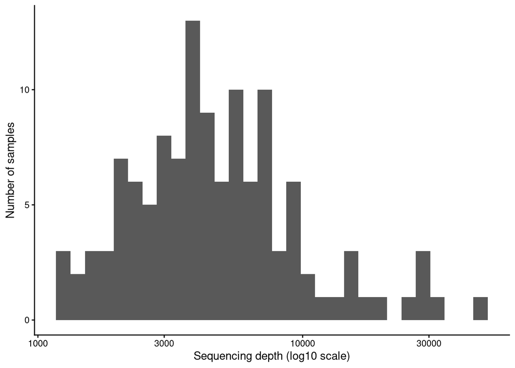

```r
#GAH why was that so hard!
#plotting

seq_depth_df_1200 <- data.frame(
  Sample = names(sample_sums(physeq_depth1200)),
  Depth = as.numeric(sample_sums(physeq_depth1200))
)

ggplot(seq_depth_df_1200, aes(x = Depth)) +
  geom_histogram(bins = 30) +
  scale_x_log10() +
  labs(x = "Sequencing depth (log10 scale)", y = "Number of samples")+
  theme_classic()
```

```r
#fine. I'm moving on.
# seqSums_df %>%
#   dplyr::select(Run, TotalSeqs) %>%
#   arrange(TotalSeqs)
num_samples <- nsamples(physeq_depth1200)
num_samples
```

```
## [1] 122
```

```r
class(physeq_depth1200)
```

```
## [1] "phyloseq"
## attr(,"package")
## [1] "phyloseq"
```

I’ve removed anything below 1200 reads. I now have 122. The paper had 126. # samples does not change when I filter by 1000 instead. That seems wrong but it is past me.

# 8. Write out the data

Finally, let’s save our phyloseq object, which we will use for the next step!

```r
preprocessed_physeq <-
  physeq_depth1200
min(sample_sums(preprocessed_physeq)) #1247??
```

```
## [1] 1247
```

```r
# seqSums_df %>%
#   dplyr::select(Run, TotalSeqs) %>%
#   arrange(TotalSeqs)
seqSums_df <- data.frame(
  Run = names(sample_sums(physeq_depth1200)),
  TotalSeqs = as.numeric(sample_sums(physeq_depth1200))
) %>%
  dplyr::arrange(TotalSeqs)
seqSums_df #good
```

```
##             Run TotalSeqs
## 1   SRR11917154      1247
## 2   SRR11917087      1298
## 3   SRR11917071      1325
## 4   SRR11917228      1378
## 5   SRR11917175      1396
## 6   SRR11917088      1561
## 7   SRR11917095      1588
## 8   SRR11917181      1654
## 9   SRR11917118      1747
## 10  SRR11917226      1864
## 11  SRR11917151      1894
## 12  SRR11917231      1959
## 13  SRR11917299      1992
## 14  SRR11917286      2015
```

[output cut: 108 more lines]

```r
# Please be sure to use the correct path to the appropriate directory in your file system
save(preprocessed_physeq, file = "/local/workdir/erw98/Brassica_Growth_2026/data/03_PreProcessing/preprocessed_phyloseq.RData")
```

# Final info for Reproducibility

## Check Render Time

```r
# Take the time now that we are at the end of the script
end_time <- Sys.time()
end_time
```

```
## [1] "2026-04-23 18:21:03 EDT"
```

```r
# Echo the elapsed time
elapsed_time <- round((end_time - start_time), 3)
elapsed_time
```

```
## Time difference of 17.933 secs
```